# Pokedex_html

## Building a Pokedex using CNNs

[figure not shown]

### Gotta Classify Them All!

In this blog I will be attempting to build out a convolutional neural network that classifies 1st gen Pokemon. I wanted to play around with some CNNs and quickly settled on this nostalgic idea. Its hardly an original idea and there are number of other attempts out there, but I wanted to give it a go nonetheless and see if I can improve on what's come before.

### The Dataset

I made a couple of edits to the simple-image-downloader package to stop it from producing an error when a request timed out, so that it would be able to run without me having to restart it. It was this process of restarting that often gave me the duplicate images and hence was an important step. If you'd like to see use my version of simple-image-downloader then please see the Pokedex repository on my Github.

### Exploring the Data

Like all good data science projects I started with some exploratory data analysis. For this project I will be using Tensorflow, as well as a few other standard libraries to help process and display the data and results.

```python
import tensorflow as tf
import numpy as np
import pandas as pd
from PIL import Image, ImageFile
import matplotlib.pyplot as plt
import seaborn as sns
import pathlib
import os
```

```python
os.environ['TF_CPP_MIN_LOG_LEVEL'] = '3'
tf.get_logger().setLevel('ERROR')
tf.compat.v1.logging.set_verbosity(tf.compat.v1.logging.ERROR)
```

```python
tf.__version__
```

```
'2.16.2'
```

First, I wanted to inspect the spread in picture sizes of the dataset.

```python
# Setting the path for images
image_path = '/Users/adam/Portfolio/Pokedex/PokemonData'

# Getting a list of all image filenames
image_folders = os.listdir(image_path)
image_folders.remove(".DS_Store")
```

```python
image_dims = []
for img_folder in image_folders:
    list_dir = os.listdir(os.path.join(image_path, img_folder))
    try:
        list_dir.remove(".DS_Store")
    except:
        pass
    for img in list_dir:
        img = Image.open(os.path.join(image_path, img_folder, img))
        image_dims.append((img.height, img.width))
```

```python
image_dims = pd.DataFrame(image_dims, columns=["height","width"])
```

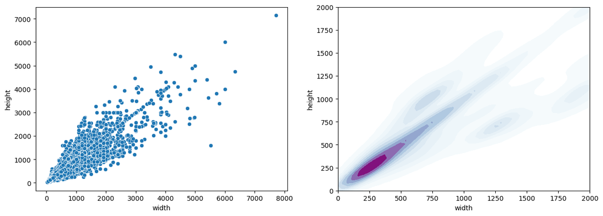

```python
fig, axes = plt.subplots(1, 2, figsize=(15, 5))
axes[1].set_xlim([0,2000])
axes[1].set_ylim([0,2000])


sns.scatterplot(x=image_dims["width"], y=image_dims["height"], ax=axes[0])
sns.kdeplot(x=image_dims["width"], y=image_dims["height"], ax=axes[1], fill=True, cmap="BuPu")
plt.show()
```

The plots show a large spread of picture sizes, all the way up to 6000+ pixels. The KDE plot neatly shows that the vast majority of the pictures have heights and widths between 200 and 500 pixels.

Now let's load the data. I'm going to format all the images to 224 x 224, since this is a common image size in the dataset (it is also a key hyperparameter and the choice of 224 will be become evident later).

Note, the data only has 149 classes, as Nidoran was removed from the original dataset. I suspect this is because it takes male and female forms that look different but have the same name, and hence would confuse the model. By the time I realised this I had already boosted the dataset and so didn't go back to add them in. Sorry Nidoran.

[figure not shown]

To load the data I will set up a Tensorflow pipeline which will work efficiently when training the model and help implement data augmentation.

```python
image_path = '/Users/adam/Portfolio/Pokedex/PokemonData'
data_dir = pathlib.Path(image_path).with_suffix('')

batch_size = 32
img_height = 224
img_width = 224

train_ds = tf.keras.utils.image_dataset_from_directory(
    data_dir,
    validation_split=0.1,
    subset="training",
    seed=123,
    image_size=(img_height, img_width),
    batch_size=batch_size,
    color_mode="rgb",
    label_mode="categorical"
)

val_ds = tf.keras.utils.image_dataset_from_directory(
    data_dir,
    validation_split=0.1,
    subset="validation",
    seed=123,
    image_size=(img_height, img_height),
    batch_size=batch_size,
    color_mode="rgb",
    label_mode="categorical")

class_names = train_ds.class_names

AUTOTUNE = tf.data.AUTOTUNE

train_ds = train_ds.cache().prefetch(buffer_size=AUTOTUNE)
val_ds = val_ds.cache().prefetch(buffer_size=AUTOTUNE)
```

```
Found 26793 files belonging to 149 classes.
Using 24114 files for training.
Found 26793 files belonging to 149 classes.
Using 2679 files for validation.
```

I'm now going to manually save the number of samples in each dataset since there is seemingly no way of accessing this through `tf.data.Datasets` once it has been batched.

```python
train_samples = 24114
val_samples = 2679
```

Now, to have a sneak peak at some of the data:

[figure not shown]

```python
poke_labels = []
for (image_batch, label_batch) in train_ds.as_numpy_iterator():
    img_np = np.array(image_batch)
    for label in label_batch:
        poke_labels.append(class_names[np.argmax(np.array(label))])
    break


fig = plt.figure(figsize=(12,6))
for i in range(len(poke_labels)//2):
    plt.subplot(4,8,int(i)+1)
    plt.imshow(img_np[i,:,:,:]/255, )
    plt.title(label=poke_labels[i])
    plt.axis('off')

plt.tight_layout()
plt.show()
```

Next, let's look at the spread of images per class:

```python
poke_dict = {}
poke_list = os.listdir(image_path)
poke_list.remove('.DS_Store')

for poke in poke_list:
    file_list = os.listdir(image_path + "/" + poke)
    poke_dict[poke] = len(file_list)

poke_pd = pd.DataFrame.from_dict(poke_dict, orient="index", columns=["count"]).sort_values("count")
```

[figure not shown]

```python
fig = plt.figure(figsize=(12,6))

plt.subplot(2, 1, 1)
plt.plot(poke_pd)
plt.xticks([],)
plt.ylabel("Number of Images")
plt.title("Number of images across all Classes")

plt.subplot(2, 2, 3)
plt.plot(poke_pd.head(20))
plt.ylabel("Number of Images")
plt.xticks(rotation = 90)
plt.title("20 Classes with Least Images")

plt.subplot(2, 2, 4)
plt.plot(poke_pd.tail(20))
plt.xticks(rotation = 90)
plt.title("Number of images across all Classes")
plt.title("20 Classes with Most Images")

plt.show()
```

We can see the range of images per class goes from around 140 to 240, with the median around 180. This might seem a large spread, but is a much more stable spread than the original dataset. It will be interesting to see if the number of images per class impacts the accuracy of the model at predicting that class.

### Prepping the Data

Before I trained the model I set up a data pipeline which tune the image size and batch size hyperparameters as well as some data augmentation. I experimented with some other augmentation techniques, like adjusting the hue of the images, however, this damaged the performance since the image relies heavily on colour to classify the Pokemon. Note, I have not not rescaled the data at the moment.

```python
from tensorflow.keras import layers, models

IMG_SIZE = 224
AUTOTUNE = tf.data.AUTOTUNE
batch_size = 64

resize = tf.keras.Sequential([
    layers.Resizing(IMG_SIZE, IMG_SIZE),
#     layers.Rescaling(1./255)
])

data_augmentation = tf.keras.Sequential([
    layers.RandomFlip("horizontal"),
    layers.RandomRotation(0.25),
    layers.RandomZoom(height_factor=(-0.2, 0), width_factor=(-0.2, 0)),

])

def prepare(ds, shuffle=False, augment=False):
  # Resize datasets.
    ds = ds.map(lambda x, y: (resize(x), y),
              num_parallel_calls=AUTOTUNE)


    if shuffle:
        ds = ds.shuffle(1000)


  # Use data augmentation only on the training set.
    if augment:
        ds = ds.map(lambda x, y: (data_augmentation(x, training=True), y),
                num_parallel_calls=AUTOTUNE)

    ds = ds.rebatch(batch_size)
  # Use buffered prefetching on all datasets.
    return ds.prefetch(buffer_size=AUTOTUNE)

train_ds = prepare(train_ds, shuffle=True, augment=True)
val_ds = prepare(val_ds)
```

### Defining the Model

```python
MobNet = tf.keras.applications.MobileNetV3Small(input_shape=(IMG_SIZE, IMG_SIZE, 3), include_top=False)
MobNet.summary()
```

```
Model: "MobileNetV3Small"
```

[output not shown]

```
 Total params: 1,127,429 (4.30 MB)
```

```
 Trainable params: 1,114,165 (4.25 MB)
```

```
 Non-trainable params: 13,264 (51.81 KB)
```

Now for fitting the model. I used the Adam optimizer and after trying some learning rates I decided that to start on 0.001 and to reduce on plateau was the most efficient.

The image size was the most impactful hyperparameter on the final accuracy of the model, but also had a significant negative impact training time. I settled on 224 as it was the image size that MobileNet was trained on and produced good results. The batch size that worked best on my CPU was 64, but the impact was small.

```python
from tensorflow.keras.callbacks import EarlyStopping, ReduceLROnPlateau
from tensorflow.keras.optimizers import Adam, SGD

opt = Adam(learning_rate=0.001)
early_stop = EarlyStopping(monitor='val_accuracy', mode='max', patience=5,  restore_best_weights=True)
reduce_lr = ReduceLROnPlateau(monitor="val_loss", factor=0.1, patience=3, min_lr=0.00001)

model.compile(optimizer=opt, loss='categorical_crossentropy', metrics=['accuracy'])

model.fit(train_ds, epochs=100,  callbacks=[early_stop, reduce_lr], verbose=False, validation_data=val_ds,
          steps_per_epoch=train_samples//batch_size+1, validation_steps=val_samples//batch_size+1)
```

```python
model = tf.keras.models.load_model("mobnet_224.keras")
model.load_weights("mobnet_v3.weights.h5")
val_ds = tf.data.Dataset.load("tf_data/val_ds")
```

Let's see how the model performed!

```python
# val_ds = val_ds.repeat(1)
loss, accuracy = model.evaluate(val_ds, steps=val_samples//batch_size+1)
```

```
42/42 ━━━━━━━━━━━━━━━━━━━━ 23s 469ms/step - accuracy: 0.9780 - loss: 0.0841
```

```python
print(f"The final validation accuracy is {round(accuracy*100,1)}%!\nThe final validation loss is {round(loss,4)}!")
```

```
The final validation accuracy is 97.7%!
The final validation loss is 0.0856!
```

A final validation accuracy of 97.7%. I am really happy with these results, well done MobileNet! Even though the training was still slow and I had to leave it running overnight.

Finally, lets look into our predictions and the sources of error. I do this be compiling a list of the correct and predicted Pokemon in the validation set as well as the image as an array.

```python
# val_ds = val_ds.repeat(1)
y_true = []

img_np = np.array(next(iter(val_ds))[0])
for img_batch, label_batch in val_ds:
    img_np = np.concatenate((img_np,img_batch))
    for label in label_batch:
        y_true.append(class_names[np.argmax(np.array(label))])

img_np = img_np[64:,:,:,:]
```

```python
img_np.shape
```

```
(2679, 224, 224, 3)
```

```python
y_pred = model.predict(val_ds, steps=val_samples//batch_size+1)
y_pred_lab = []

for pred in y_pred:
    y_pred_lab.append(class_names[np.argmax(pred)])
```

```
42/42 ━━━━━━━━━━━━━━━━━━━━ 37s 836ms/step
```

Then define a list of every misclassified image:

```python
pics = [i for i in range(len(y_true)) if (y_true[i]!=y_pred_lab[i])]
len(pics)
```

```
67
```

We have 67 misclassified images.

[figure not shown]

```python
fig = plt.figure(figsize=(12,40))
for i in range(len(pics)):
    plt.subplot(25,8,int(i)+1)
    plt.imshow(img_np[pics[i],:,:,:]/255, )
    plt.title(label= "True: " + y_true[pics[i]] + "\n Pred: " + y_pred_lab[pics[i]])
    plt.axis("off")

plt.tight_layout()
plt.show()
```

By my count about 10 of these are due to the wrong or more than one Pokemon being shown. Another 10 are misclassifying within the same evolutions e.g. predicting Machoke for a Machamp or Dewgong for a Seel, a forgivable mistake. Finally, many of the other misclassified predictions arise from atypical colours in the image, such as the shiny Tauros and Machamp Pokemon cards or the pink Drowzee predicted as Clefable.

Overall, most of these inaccurate predictions would be removed by fewer mistakes in the validation data or less ambiguous images. Whether you want to go down this route depends on what you intend the model to do, should it be fairly accurate at predicting low res images with a lot of noise or should it be very good at predicting good images that look like a typical depiction of that Pokemon. For now I think 97.7% is very satisfactory and the highest I have seen on the internet.

The logical next step for this project would be to create an operational app for the model to make predictions, and I believe given good inputs it would perform very well. This is something I intend to tackle in the future.

### Project Learnings

First, the greatest difficulty of the project was the slow training time. I spent a long time trying to get my GPU to work before realising it was not supported. I also had great difficulty getting cloud GPU services to work since the file upload to Google Colab/Drive was erroring often and very slow - something for me to figure out in the future. While MobileNet worked well it was still slower than I'd have liked. Next time I will experiment with freezing a certain number of MobileNet layers and see if I can obtain similar performance.

Second, I learnt not only the importance of data augmentation and that more is not always better. For example, it would be rare to get an image of a Pokemon vertically flipped, as a result augmenting the data in the way was not useful, similarly adjusting the hue of the image made it much hard for the network to learn.

Finally, the quality of data matter hugely to a project like this. I believe I was able to achieve superior accuracy due to the fact I increased the dataset size, however, I am still being let down by incorrectly labeled images or poorly cropped images.

I hope you enjoyed reading and can take inspiration for your own projects in the future!